# Project: No-show Appointments Data Analysis

## Exploratory Data Analysis

### Is the patient's age associated with attendance?

```python
# we can create two masks for the people who came to appointment and patients
# who did not attend it. This will enable to create clear comparisons and accurate plots.
show = df.no_show == 'No'
no_show = df.no_show == 'Yes'
```

```python
# we can find out the average age of patients who attended the appointment and those who did not.
print(df.age[no_show].mean())
print(df.age[show].mean())
```

```
34.3176665621
37.7900643933
```

> We can see that the average age of attended patients is more with 3.5 years.

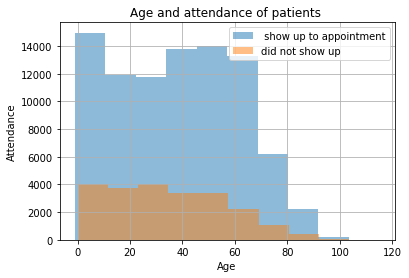

```python
# By ploting the show and no_show ages we can see more clearly which age do
# both attended and not attended patients have.
df.age[show].hist(alpha=0.5, label=' show up to appointment')
df.age[no_show].hist(alpha=0.5, label='did not show up')
plt.legend()
plt.title("Age and attendance of patients ")
plt.xlabel("Age")
plt.ylabel("Attendance");
```

> It is visible that patients of age 10-35 have higher rate of non-attendance rather than patiens with age 0-10 and 35-60. Patiens of age 60-70 have lower non-attendance rate in comparison with other ages.

### Is the received sms associated with attendance?

```python
# We can execute the same steps to find an association between attendance and sms receiving.
# Check the prportions of attended and not attended patients who received reminding sms.
print(df.sms_received[show].mean())
print(df.sms_received[no_show].mean())
```

```
0.291334119354
0.438370894753
```

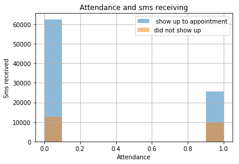

```python
# we can create plot to see the results visualised
df.sms_received[show].hist(alpha=0.5, label=' show up to appointment')
df.sms_received[no_show].hist(alpha=0.5, label='did not show up')
plt.legend()
plt.title("Attendance and sms receiving")
plt.xlabel("Attendance")
plt.ylabel("Sms received");
```

As we see, the rate of patients who received a riminder sms and didn't show up is higher than the rate of patients who received an sms and did show up.

### Is the handicap associated with attendance?

```python
print(df.handcap[no_show].mean())
print(df.handcap[show].mean())
```

```
0.020296608271
0.022741701433
```

> We can see that more patients with handcap show up to appointments than patients without handcap.

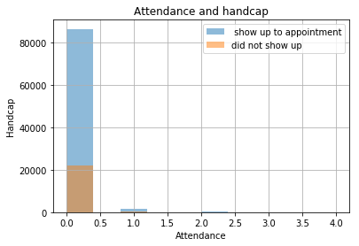

```python
df.handcap[show].hist(alpha=0.5, label=' show up to appointment')
df.handcap[no_show].hist(alpha=0.5, label='did not show up')
plt.legend()
plt.title("Attendance and handcap")
plt.xlabel("Attendance")
plt.ylabel("Handcap");
```

> Since the number of petients with handcap is not high, we cannot see clearly the the attendance of patients with handcap and without it in the histogram. So, we can have a look on the patients with handcap separately.

```python
# create a new dataframe which includes patients only with handcap
df_handcap = df.query('handcap == 1')
```

```python
# create masks with for the dataframe with handcap patients
show_hand = df_handcap.no_show == 'No'
no_show_hand = df_handcap.no_show == 'Yes'
```

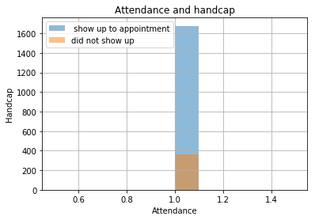

```python
# create a histogram for patients which have handcap
df_handcap.handcap[show_hand].hist(alpha=0.5, label=' show up to appointment')
df_handcap.handcap[no_show_hand].hist(alpha=0.5, label='did not show up')
plt.legend()
plt.title("Attendance and handcap")
plt.xlabel("Attendance")
plt.ylabel("Handcap");
```

> We can clearly see that substantially more patients with handcap show up to their appointments than the patients with handcap who did not show up.

> The correlation of previously and currently discussed categories - age and handcap can make it clrearer how the handcap levels are spreaded in the dataset. Best way to see the relationship of these categories could be scatter plot.

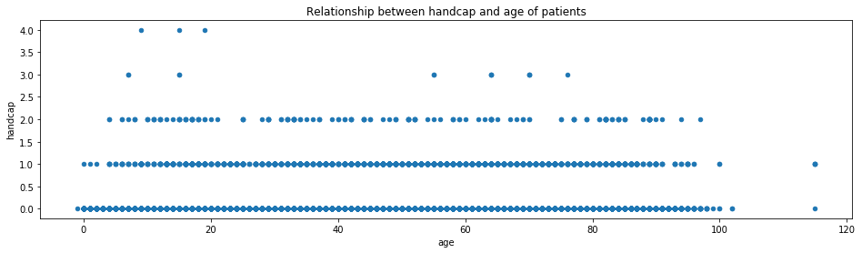

```python
df.plot(x='age', y='handcap', kind='scatter', figsize = (16,4))
plt.title("Relationship between handcap and age of patients");
```

> We can see that there are 4 levels of handcap. The higher level the less the patients with handcap and also the increase of age reduces the number of patients with handicap.

### Which are the neighbourhoods which have most of the patient who didn't show up?

```python
# creeate a datafram only with the patient information who didn't show up
df_noshow = df.query('no_show == "Yes"')
df_noshow.head()
```

|  | patientid | gender | age | neighbourhood | scholarship | hipertension | diabetes | alcoholism | handcap | sms_received | no_show |
| --- | --- | --- | --- | --- | --- | --- | --- | --- | --- | --- | --- |
| 6 | 7.336882e+14 | F | 23 | GOIABEIRAS | 0 | 0 | 0 | 0 | 0 | 0 | Yes |
| 7 | 3.449833e+12 | F | 39 | GOIABEIRAS | 0 | 0 | 0 | 0 | 0 | 0 | Yes |
| 11 | 7.542951e+12 | M | 29 | NOVA PALESTINA | 0 | 0 | 0 | 0 | 0 | 1 | Yes |
| 17 | 1.479497e+13 | F | 40 | CONQUISTA | 1 | 0 | 0 | 0 | 0 | 0 | Yes |
| 20 | 6.222575e+14 | F | 30 | NOVA PALESTINA | 0 | 0 | 0 | 0 | 0 | 0 | Yes |

```python
# check how many repetitions have the top 20 neighbourhood areas in dataframe
df_noshow.neighbourhood.value_counts().head(20)
```

```
JARDIM CAMBURI       1465
MARIA ORTIZ          1219
ITARARÉ               923
RESISTÊNCIA           906
CENTRO                703
JESUS DE NAZARETH     696
JARDIM DA PENHA       631
CARATOÍRA             591
TABUAZEIRO            573
BONFIM                550
ILHA DO PRÍNCIPE      532
ANDORINHAS            521
SÃO PEDRO             515
SANTO ANDRÉ           508
SANTA MARTHA          496
SANTO ANTÔNIO         484
ROMÃO                 474
GURIGICA              456
JABOUR                451
DA PENHA              429
Name: neighbourhood, dtype: int64
```

> Since there are many neighbourhoods which have only few repetitions in the dataset, we will consider only the most repeated areas and will create our chart only with those neighbourhoods which have more than 500 repetitions, which means more than 500 patients didn't show up from those neighbourhoods.

```python
df_noshow.neighbourhood.value_counts().loc[lambda x: x>500]
```

```
JARDIM CAMBURI       1465
MARIA ORTIZ          1219
ITARARÉ               923
RESISTÊNCIA           906
CENTRO                703
JESUS DE NAZARETH     696
JARDIM DA PENHA       631
CARATOÍRA             591
TABUAZEIRO            573
BONFIM                550
ILHA DO PRÍNCIPE      532
ANDORINHAS            521
SÃO PEDRO             515
SANTO ANDRÉ           508
Name: neighbourhood, dtype: int64
```

```python
# create new dataframe of those neighbourhoods which have more than 500 not attended patients.
df_top_neighbourhood = df_noshow.neighbourhood.value_counts().loc[lambda x: x>500]
```

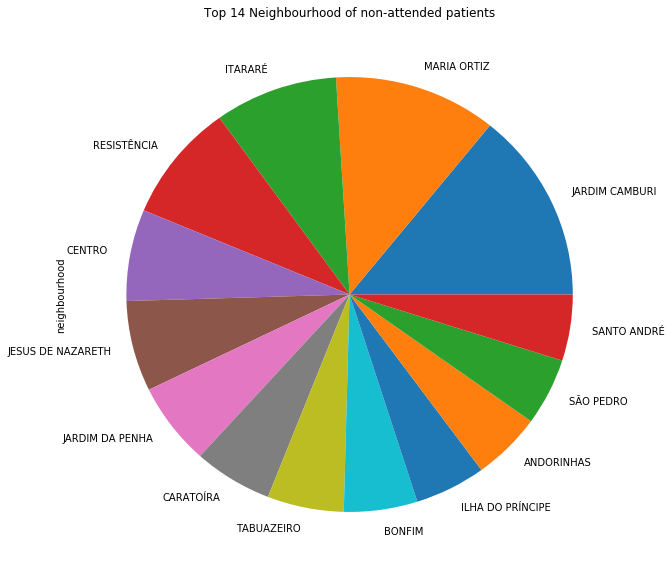

```python
df_top_neighbourhood.plot(kind='pie', figsize = (10,10))
plt.title("Top 14 Neighbourhood of non-attended patients");
```

> In our pie chart we can see that many of not attended patients are from these 5 top neighbourhoods: JARDIM CAMBURI, MARIA ORTIZ, ITARARÉ, RESISTÊNCIA, CENTRO.

## Conclusions

> Limitations: During the analysis we could face a problem of incompleteness of sms_received category. It could be useful to have more details about this category such as how many times and when were the reminders sent.

```python
from subprocess import call
call(['python', '-m', 'nbconvert', 'Investigate_a_Dataset.ipynb'])
```

```
0
```